# My first R Markdown file

What is mean total number of steps taken per day?

1. Calculate the total number of steps taken per day
2. If you do not understand the difference between a histogram and a barplot, research the difference between them. Make a histogram of the total number of steps taken each day
3. Calculate and report the mean and median of the total number of steps taken per day

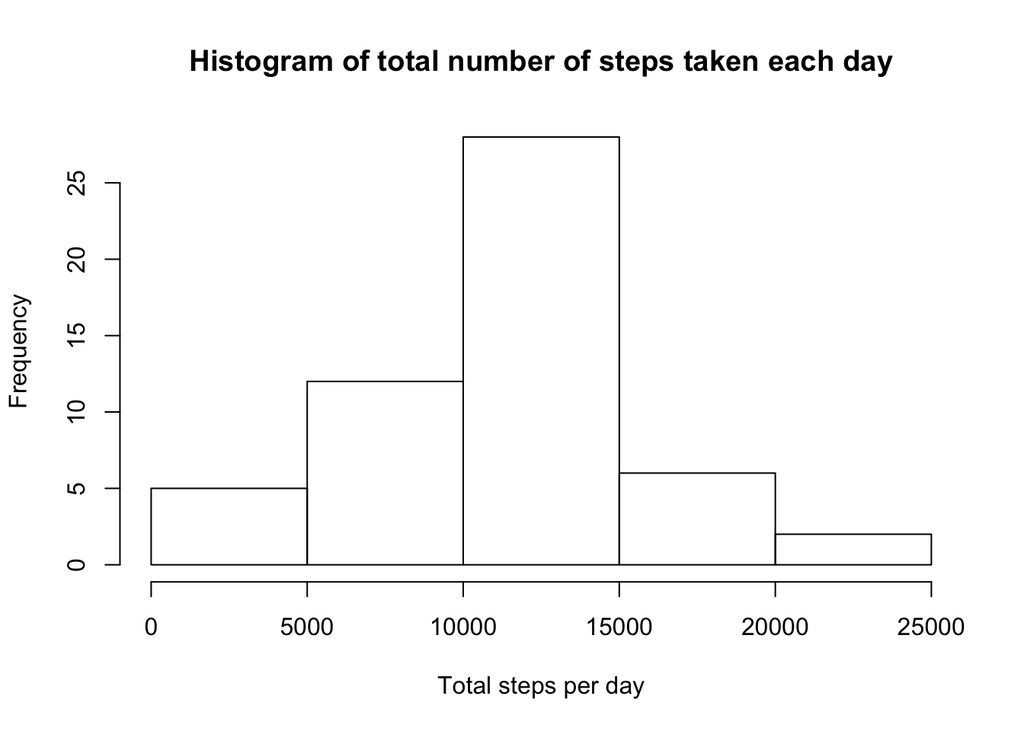

```r
d1<-aggregate(steps~date,d0,sum)
hist(d1$steps,xlab = "Total steps per day",main = "Histogram of total number of steps taken each day")
```

```r
summary(d1$steps)
```

```
##    Min. 1st Qu.  Median    Mean 3rd Qu.    Max.
##      41    8841   10765   10766   13294   21194
```

What is the average daily activity pattern?

1. Make a time series plot of the 5-minute interval (x-axis) and the average number of steps taken, averaged across all days (y-axis)
2. Which 5-minute interval, on average across all the days in the dataset, contains the maximum number of steps?

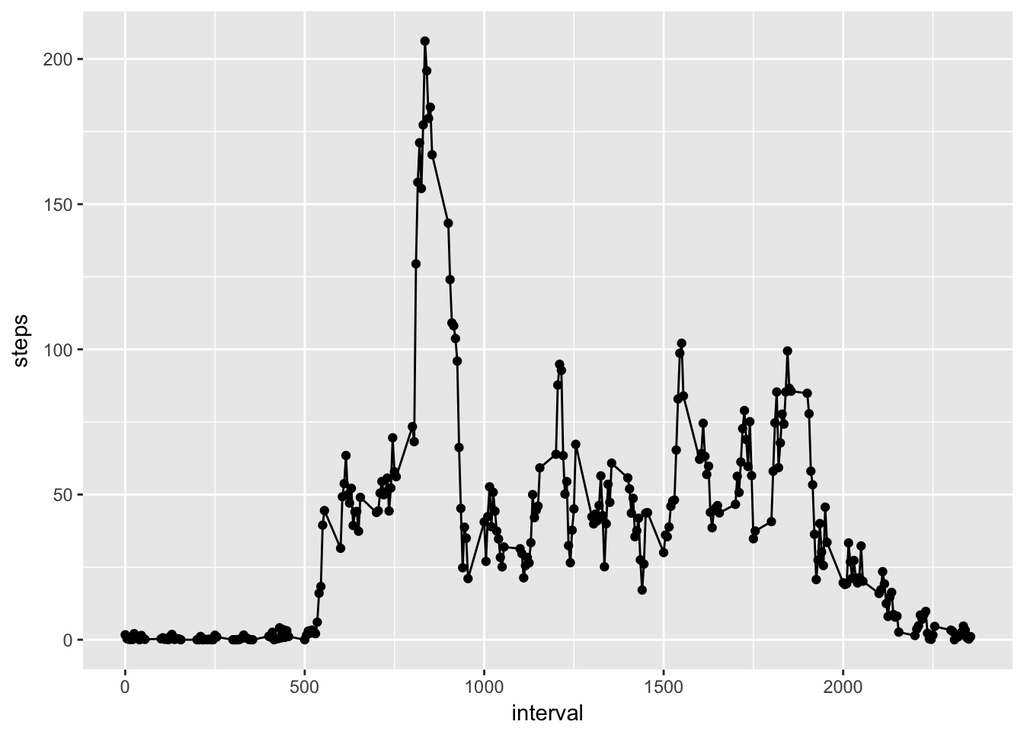

```r
d2<-aggregate(steps~interval,d0,mean)
ggplot(d2,aes(x=interval,y=steps))+geom_point()+geom_line()
```

```r
head(arrange(d2,desc(steps)),n=1)
```

```
##   interval    steps
## 1      835 206.1698
```

Imputing missing values

Note that there are a number of days/intervals where there are missing values. The presence of missing days may introduce bias into some calculations or summaries of the data.